# Определение перспективного тарифа для телеком компании

Компания «Мегалайн» — федеральный оператор сотовой связи.  
Клиентам предлагают два тарифных плана: «Смарт» и «Ультра». Чтобы скорректировать рекламный бюджет, коммерческий департамент хочет понять, какой тариф приносит больше денег. Нам предстоит сделать предварительный анализ тарифов на небольшой выборке клиентов. В нашем распоряжении данные 500 пользователей «Мегалайна»: кто они, откуда, каким тарифом пользуются, сколько звонков и сообщений каждый отправил за 2018 год. Нужно проанализировать поведение клиентов и сделать вывод — какой тариф лучше.

### Описание тарифов

### Тариф «Смарт»

Ежемесячная плата: 550 рублей  
Включено 500 минут разговора, 50 сообщений и 15 Гб интернет-трафика  
Стоимость услуг сверх тарифного пакета:  
минута разговора: 3 рубля  
сообщение: 3 рубля  
1 Гб интернет-трафика: 200 рублей

### Тариф «Ультра»

Ежемесячная плата: 1950 рублей  
Включено 3000 минут разговора, 1000 сообщений и 30 Гб интернет-трафика  
Стоимость услуг сверх тарифного пакета:  
минута разговора: 1 рубль  
сообщение: 1 рубль  
1 Гб интернет-трафика: 150 рублей

## План предварительного анализа тарифов компании "Мегалайн"

1. Откроем файлы с данными и изучим общую информацию

2. Подготовим данные:

```
- Приведем данные к нужным типам
- Найдем и исправим ошибки в данных
- Посчитаем для каждого пользователя:
    - количество сделанных звонков и израсходованных минут разговора по месяцам;
    - количество отправленных сообщений по месяцам;
    - объем израсходованного интернет-трафика по месяцам;
    - помесячную выручку с каждого пользователя.
```

3. Проанализируем данные:

```
- Опишем поведение клиентов оператора, исходя из выборки
- Сколько минут разговора, сколько сообщений и какой объём интернет-трафика требуется пользователям каждого тарифа в месяц?
- Посчитаем среднее количество, дисперсию и стандартное отклонение
- Построем гистограммы
- Опишем распределения
```

4. Проверим гипотезы:

```
- средняя выручка пользователей тарифов «Ультра» и «Смарт» различается;
- средняя выручка пользователей из Москвы отличается от выручки пользователей из других регионов;
```

5. Сформулируем общий вывод

### 1. Откроем файлы с данными и изучим общую информацию

### Импорт библиотек

```python
import pandas as pd
import numpy as np
from matplotlib import pyplot as plt
from math import factorial
from scipy import stats as st
```

### Откроем файлы

```python
calls = pd.read_csv('/datasets/calls.csv')
internet = pd.read_csv('/datasets/internet.csv')
messages = pd.read_csv('/datasets/messages.csv')
tariffs = pd.read_csv('/datasets/tariffs.csv')
users = pd.read_csv('/datasets/users.csv')
```

Всего у нас 5 таблиц.  
**1.1 Изучим данные таблицы calls**

```python
calls.head()
```

|  | id | call_date | duration | user_id |
| --- | --- | --- | --- | --- |
| 0 | 1000_0 | 2018-07-25 | 0.00 | 1000 |
| 1 | 1000_1 | 2018-08-17 | 0.00 | 1000 |
| 2 | 1000_2 | 2018-06-11 | 2.85 | 1000 |
| 3 | 1000_3 | 2018-09-21 | 13.80 | 1000 |
| 4 | 1000_4 | 2018-12-15 | 5.18 | 1000 |

Получим общую информацию о данных таблицы

```python
calls.info()
```

```
<class 'pandas.core.frame.DataFrame'>
RangeIndex: 202607 entries, 0 to 202606
Data columns (total 4 columns):
id           202607 non-null object
call_date    202607 non-null object
duration     202607 non-null float64
user_id      202607 non-null int64
dtypes: float64(1), int64(1), object(2)
memory usage: 6.2+ MB
```

### Описание даных:

- id — уникальный номер звонка
- call_date — дата звонка
- duration — длительность звонка в минутах
- user_id — идентификатор пользователя, сделавшего звонок

```python
calls['id'].describe()
```

```
count       202607
unique      202607
top       1036_377
freq             1
Name: id, dtype: object
```

В столбце id нет пропусков и повторяющихся значений, тип данных object соответствует требуемому

```python
calls['call_date'].describe()
```

```
count         202607
unique           365
top       2018-12-31
freq            1435
Name: call_date, dtype: object
```

```python
calls['call_date'].min()
```

```
'2018-01-01'
```

```python
calls['call_date'].max()
```

```
'2018-12-31'
```

Столбец call_date не содержит пропусков. В столбце указано 365 дней звонков за 2018 год: с 01 января по 31 декабря. Тип данных object не соответствует требуемому datetime

```python
calls['duration'].describe()
```

```
count    202607.000000
mean          6.755887
std           5.843365
min           0.000000
25%           1.300000
50%           6.000000
75%          10.700000
max          38.000000
Name: duration, dtype: float64
```

```python
len(calls.query('duration == 0'))
```

```
39613
```

Столбец duration не содержит пропусков. Тип данных float соответствует требуемому. Столбец содержит 39613 нулевых значений длительности звонков

```python
len(calls['user_id'].value_counts())
```

```
492
```

```python
calls['user_id'].isna().sum()
```

```
0
```

Столбец user_id не содержит пропуски, содержит информацию о 492 пользователях. Тип данных integer соответствует требуемому

**1.2 Изучим данные таблицы internet**

```python
internet.head()
```

|  | Unnamed: 0 | id | mb_used | session_date | user_id |
| --- | --- | --- | --- | --- | --- |
| 0 | 0 | 1000_0 | 112.95 | 2018-11-25 | 1000 |
| 1 | 1 | 1000_1 | 1052.81 | 2018-09-07 | 1000 |
| 2 | 2 | 1000_2 | 1197.26 | 2018-06-25 | 1000 |
| 3 | 3 | 1000_3 | 550.27 | 2018-08-22 | 1000 |
| 4 | 4 | 1000_4 | 302.56 | 2018-09-24 | 1000 |

Получим общую информацию о данных таблицы

```python
internet.info()
```

```
<class 'pandas.core.frame.DataFrame'>
RangeIndex: 149396 entries, 0 to 149395
Data columns (total 5 columns):
Unnamed: 0      149396 non-null int64
id              149396 non-null object
mb_used         149396 non-null float64
session_date    149396 non-null object
user_id         149396 non-null int64
dtypes: float64(1), int64(2), object(2)
memory usage: 5.7+ MB
```

### Описание данных

Информация об интернет-сессиях:

- id — уникальный номер сессии
- mb_used — объём потраченного за сессию интернет-трафика (в мегабайтах)
- session_date — дата интернет-сессии
- user_id — идентификатор пользователя

В таблице присутствует ненужный столбец Unnamed: 0, дублирующий индексацию данных. От него надо избавиться.  
Все столбцы не содержат пропусков

```python
internet['id'].describe()
```

```
count      149396
unique     149396
top       1239_55
freq            1
Name: id, dtype: object
```

В столбце id нет пропусков и повторяющихся значений, тип данных object соответствует требуемому

```python
len(internet.query('mb_used == 0'))
```

```
19598
```

Столбец mb_used не содержит пропусков. Тип данных float соответствует требуемому. Столбец содержит 19598 нулевых значений объема потраченного интернет-трафика

```python
internet['session_date'].describe()
```

```
count         149396
unique           365
top       2018-12-31
freq            1057
Name: session_date, dtype: object
```

```python
internet['session_date'].min()
```

```
'2018-01-01'
```

```python
internet['session_date'].max()
```

```
'2018-12-31'
```

Столбец session_date не содержит пропусков. В столбце указано 365 дней интернет-сессий за 2018 год: с 01 января по 31 декабря. Тип данных object не соответствует требуемому datetime

```python
len(internet['user_id'].value_counts())
```

```
497
```

Столбец user_id не содержит пропуски, содержит информацию о 497 пользователях. Тип данных integer соответствует требуемому

**1.3 Изучим данные таблицы messages**

```python
messages.head()
```

|  | id | message_date | user_id |
| --- | --- | --- | --- |
| 0 | 1000_0 | 2018-06-27 | 1000 |
| 1 | 1000_1 | 2018-10-08 | 1000 |
| 2 | 1000_2 | 2018-08-04 | 1000 |
| 3 | 1000_3 | 2018-06-16 | 1000 |
| 4 | 1000_4 | 2018-12-05 | 1000 |

Получим общую информацию о данных таблицы

```python
messages.info()
```

```
<class 'pandas.core.frame.DataFrame'>
RangeIndex: 123036 entries, 0 to 123035
Data columns (total 3 columns):
id              123036 non-null object
message_date    123036 non-null object
user_id         123036 non-null int64
dtypes: int64(1), object(2)
memory usage: 2.8+ MB
```

### Описание данных

- id — уникальный номер сообщения
- message_date — дата сообщения
- user_id — идентификатор пользователя, отправившего сообщение

```python
messages['id'].describe()
```

```
count      123036
unique     123036
top       1239_55
freq            1
Name: id, dtype: object
```

В столбце id нет пропусков и повторяющихся значений, тип данных object соответствует требуемому

```python
messages['message_date'].describe()
```

```
count         123036
unique           364
top       2018-12-31
freq             859
Name: message_date, dtype: object
```

```python
messages['message_date'].min()
```

```
'2018-01-02'
```

```python
messages['message_date'].max()
```

```
'2018-12-31'
```

Cтолбец message_date не содержит пропусков. В столбце указано 364 дня, когда были отправлены сообщения за 2018 год: с 02 января по 31 декабря. Тип данных object не соответствует требуемому datetime

```python
len(messages['user_id'].value_counts())
```

```
426
```

Столбец user_id не содержит пропуски, содержит информацию о 426 пользователях. Тип данных integer соответствует требуемому

**1.4 Изучим данные таблицы tariffs**

```python
tariffs.head()
```

|  | messages_included | mb_per_month_included | minutes_included | rub_monthly_fee | rub_per_gb | rub_per_message | rub_per_minute | tariff_name |
| --- | --- | --- | --- | --- | --- | --- | --- | --- |
| 0 | 50 | 15360 | 500 | 550 | 200 | 3 | 3 | smart |
| 1 | 1000 | 30720 | 3000 | 1950 | 150 | 1 | 1 | ultra |

Получим общую информацию о данных таблицы

```python
tariffs.info()
```

```
<class 'pandas.core.frame.DataFrame'>
RangeIndex: 2 entries, 0 to 1
Data columns (total 8 columns):
messages_included        2 non-null int64
mb_per_month_included    2 non-null int64
minutes_included         2 non-null int64
rub_monthly_fee          2 non-null int64
rub_per_gb               2 non-null int64
rub_per_message          2 non-null int64
rub_per_minute           2 non-null int64
tariff_name              2 non-null object
dtypes: int64(7), object(1)
memory usage: 256.0+ bytes
```

### Описание данных

- tariff_name — название тарифа
- rub_monthly_fee — ежемесячная абонентская плата в рублях
- minutes_included — количество минут разговора в месяц, включённых в абонентскую плату
- messages_included — количество сообщений в месяц, включённых в абонентскую плату
- mb_per_month_included — объём интернет-трафика, включённого в абонентскую плату (в мегабайтах)
- rub_per_minute — стоимость минуты разговора сверх тарифного пакета (например, если в тарифе 100 минут разговора в месяц, то со 101 минуты будет взиматься плата)
- rub_per_message — стоимость отправки сообщения сверх тарифного пакета
- rub_per_gb — стоимость дополнительного гигабайта интернет-трафика сверх тарифного пакета (1 гигабайт = 1024 мегабайта)

Таблица содержит всего две записи - информацию о тарифе smart и о тарифе ultra.  
Все столбцы не имеют пропусков и дубликатов, тип данных соответствует требуемым

**1.5 Изучим данные последней таблицы users**

```python
users.head()
```

|  | user_id | age | churn_date | city | first_name | last_name | reg_date | tariff |
| --- | --- | --- | --- | --- | --- | --- | --- | --- |
| 0 | 1000 | 52 | NaN | Краснодар | Рафаил | Верещагин | 2018-05-25 | ultra |
| 1 | 1001 | 41 | NaN | Москва | Иван | Ежов | 2018-11-01 | smart |
| 2 | 1002 | 59 | NaN | Стерлитамак | Евгений | Абрамович | 2018-06-17 | smart |
| 3 | 1003 | 23 | NaN | Москва | Белла | Белякова | 2018-08-17 | ultra |
| 4 | 1004 | 68 | NaN | Новокузнецк | Татьяна | Авдеенко | 2018-05-14 | ultra |

Получим общую информацию о данных таблицы

```python
users.info()
```

```
<class 'pandas.core.frame.DataFrame'>
RangeIndex: 500 entries, 0 to 499
Data columns (total 8 columns):
user_id       500 non-null int64
age           500 non-null int64
churn_date    38 non-null object
city          500 non-null object
first_name    500 non-null object
last_name     500 non-null object
reg_date      500 non-null object
tariff        500 non-null object
dtypes: int64(2), object(6)
memory usage: 31.4+ KB
```

### Описание данных

- user_id — уникальный идентификатор пользователя
- first_name — имя пользователя
- last_name — фамилия пользователя
- age — возраст пользователя (годы)
- reg_date — дата подключения тарифа (день, месяц, год)
- churn_date — дата прекращения пользования тарифом (если значение пропущено, то тариф ещё действовал на момент выгрузки данных)
- city — город проживания пользователя
- tariff — название тарифного плана

```python
len(users['user_id'].value_counts())
```

```
500
```

```python
users['user_id'].max()
```

```
1499
```

Столбец user_id содержит 500 уникальных записей по одной на каждого уникального клиента: от 1000 до 1499. Тип данных integer соответствует требуемому

```python
users['age'].describe()
```

```
count    500.00000
mean      46.58800
std       16.66763
min       18.00000
25%       32.00000
50%       46.00000
75%       62.00000
max       75.00000
Name: age, dtype: float64
```

Столбец age не содержит пропусков, тип данных integer соответствует требуемому

```python
users['churn_date'].describe()
```

```
count             38
unique            33
top       2018-12-03
freq               2
Name: churn_date, dtype: object
```

Столбец churn_date содержит всего лишь 38 записей, остальные - пропуски. Тип данных object не соответствует требуемому datetime

```python
users['city'].describe()
```

```
count        500
unique        76
top       Москва
freq          99
Name: city, dtype: object
```

Столбец city не содержит пропусков. Всего в нем 76 уникальных записей, то есть наименований разных городов. Тип данных object соответствует требуемому

```python
users['first_name'].describe()
```

```
count       500
unique      246
top       Радим
freq          6
Name: first_name, dtype: object
```

Столбец first_name не содержит пропусков. Всего в нем 246 уникальных записей, то есть имен. Тип данных object соответствует требуемому

```python
users['last_name'].describe()
```

```
count           500
unique          419
top       Андреенко
freq              5
Name: last_name, dtype: object
```

Столбец last_name не содержит пропусков. Всего в нем 419 уникальных записей, то есть фамилий. Тип данных object соответствует требуемому

```python
users['reg_date'].describe()
```

```
count            500
unique           270
top       2018-05-28
freq               8
Name: reg_date, dtype: object
```

```python
users['reg_date'].min()
```

```
'2018-01-01'
```

```python
users['reg_date'].max()
```

```
'2018-12-31'
```

Столбец reg_date не содержит пропусков. Всего в нем 270 уникальных записей, с 01 января по 31 декабря 2018. Тип данных object не соответствует требуемому datetime

```python
users['tariff'].value_counts()
```

```
smart    351
ultra    149
Name: tariff, dtype: int64
```

Столбец tariff не содержит пропусков. Всего две уникальные записи - название тарифа smart или ultra. Тип данных object соответствует требуемому

### Вывод

Всего для анализа у нас в наличии пять таблиц с данными. В четырех из них обнаружены следующие ошибки и несоответствия:

1. Таблица calls:
   - тип данных столбца call_date не соответствует типу datetime
   - столбец duration содержит нулевые значения длительности звонков
2. Таблица internet:
   - присутствует ненужный столбец Unnamed: 0, дублирующий индексацию данных
   - столбец mb_used содержит нулевые значения объема потраченного интернет-трафика
   - тип данных столбца session_date не соответствует требуемому datetime
3. Таблица messages:
   - тип данных столбца message_date не соответствует требуемому datetime
4. Таблица users:
   - cтолбец churn_date содержит всего лишь 38 записей, остальные - пропуски. Тип данных не соответствует требуемому datetime
   - тип данных столбца reg_date не соответствует требуемому datetime

### 2. Подготовим данные к анализу

Приведем данные столбцов с датами к нужному типу datetime

```python
calls['call_date'] = pd.to_datetime(calls['call_date'], format='%Y-%m-%d')
```

```python
internet['session_date'] = pd.to_datetime(internet['session_date'], format='%Y-%m-%d')
```

```python
messages['message_date'] = pd.to_datetime(messages['message_date'], format='%Y-%m-%d')
```

```python
users['reg_date'] = pd.to_datetime(users['reg_date'], format='%Y-%m-%d')
```

```python
users['churn_date'] = pd.to_datetime(users['churn_date'], format='%Y-%m-%d')
```

Исправим оставшиеся ошибки в данных

```python
users['churn_date'].describe()
```

```
count                      38
unique                     33
top       2018-10-03 00:00:00
freq                        2
first     2018-08-17 00:00:00
last      2018-12-30 00:00:00
Name: churn_date, dtype: object
```

Столбец churn_date содержит 92.4% пропусков. Пропуски означают, что дата расторжения договора отсутствует, то есть клиент еще не расторг договор с оператором сотовой связи. Всего столбец содержит 38 записей о расторжении договора по 500 клиентам - это 7.6% данных.  
Заполнять пропуски нулями невозможно, а вымышленной датой - не имеет смысла.  
Так как количество информации в столбце очень мало, и сама информация о расторжении клиентами договоров не влияет на анализ действующих тарифов оператора связи, столбец следует удалить

```python
users = users.drop('churn_date', axis=1)
```

```python
len(calls.query('duration == 0')) / len(calls)
```

```
0.19551644316336553
```

В столбце duration содержится почти 20% нулевых данных. Логично предположить, что нулевая длительность звонка означает неотвеченный или пропущенный вызов. 20% - это большой объем данных и отказ от него может повлиять на достоверность итоговых выводов.  
Скорее всего оператор учитывает звонки с нулевой длительностью как начало пользования услугой связи и тарифицирует их, поэтому целесообразно эти записи превратить в единицы

```python
calls.loc[calls['duration'] < 1, ['duration']] = 1
len(calls.query('duration < 1'))
```

```
0
```

```python
len(internet.query('mb_used == 0')) / len(internet)
```

```
0.13118155773916304
```

В столбце mb_used содержится 13% нулевых данных. Это тоже большой объем данных и отказываться от него нецелесообразно.  
Скорее всего оператор учитывает нулевой трафик выхода в интернет как начало пользования услугой связи и тарифицирует его, поэтому целесообразно эти записи также превратить в единицы

```python
internet.loc[internet['mb_used'] < 1, ['mb_used']] = 1
len(internet.query('mb_used < 1'))
```

```
0
```

```python
internet.columns
```

```
Index(['Unnamed: 0', 'id', 'mb_used', 'session_date', 'user_id'], dtype='object')
```

```python
internet = internet.drop('Unnamed: 0', axis=1)
```

Избавились от ненужного столбца в таблице internet

### Подготовим пользовательские данные

Посчитаем для каждого пользователя:

- количество сделанных звонков и израсходованных минут разговора по месяцам;
- количество отправленных сообщений по месяцам;
- объем израсходованного интернет-трафика по месяцам;
- помесячную выручку с каждого пользователя.

Посчитаем для каждого пользователя количество сделанных звонков и израсходованных минут разговора по месяцам

```python
calls['month'] = pd.DatetimeIndex(calls['call_date']).month
```

```python
phone = calls.pivot_table(index=['user_id', 'month'], values='duration', aggfunc=['sum', 'count'])
phone.head()
```

| user_id | month | sum duration | count duration |
| --- | --- | --- | --- |
| 1000 | 5 | 155.73 | 22 |
|  | 6 | 174.56 | 43 |
|  | 7 | 326.36 | 47 |
|  | 8 | 400.08 | 52 |
|  | 9 | 453.38 | 58 |

```python
phone.columns = ['duration', 'calls']
phone.head()
```

| user_id | month | duration | calls |
| --- | --- | --- | --- |
| 1000 | 5 | 155.73 | 22 |
|  | 6 | 174.56 | 43 |
|  | 7 | 326.36 | 47 |
|  | 8 | 400.08 | 52 |
|  | 9 | 453.38 | 58 |

Посчитаем для каждого пользователя количество отправленных сообщений по месяцам

```python
messages['month'] = pd.DatetimeIndex(messages['message_date']).month
```

```python
sms = messages.pivot_table(index=['user_id', 'month'], values='id', aggfunc='count')
sms.head()
```

| user_id | month | id |
| --- | --- | --- |
| 1000 | 5 | 22 |
|  | 6 | 60 |
|  | 7 | 75 |
|  | 8 | 81 |
|  | 9 | 57 |

```python
sms.columns = ['messages']
sms.head()
```

| user_id | month | messages |
| --- | --- | --- |
| 1000 | 5 | 22 |
|  | 6 | 60 |
|  | 7 | 75 |
|  | 8 | 81 |
|  | 9 | 57 |

Посчитаем для каждого пользователя объем израсходованного интернет-трафика по месяцам

```python
internet.head()
```

|  | id | mb_used | session_date | user_id |
| --- | --- | --- | --- | --- |
| 0 | 1000_0 | 112.95 | 2018-11-25 | 1000 |
| 1 | 1000_1 | 1052.81 | 2018-09-07 | 1000 |
| 2 | 1000_2 | 1197.26 | 2018-06-25 | 1000 |
| 3 | 1000_3 | 550.27 | 2018-08-22 | 1000 |
| 4 | 1000_4 | 302.56 | 2018-09-24 | 1000 |

```python
internet['month'] = pd.DatetimeIndex(internet['session_date']).month
```

```python
online = internet.pivot_table(index=['user_id', 'month'], values='mb_used', aggfunc='sum')
online.head()
```

| user_id | month | mb_used |
| --- | --- | --- |
| 1000 | 5 | 2254.49 |
|  | 6 | 23238.77 |
|  | 7 | 14004.64 |
|  | 8 | 14057.93 |
|  | 9 | 14570.91 |

Посчитаем помесячную выручку с каждого пользователя

Для этого объединим данные по звонкам, сообщениям и пользованию интернетом по каждому пользователю помесячно

```python
revenue = phone.merge(sms, how='left', on=['user_id','month'])
```

```python
revenue = revenue.merge(online, how='left', on=['user_id', 'month'])
revenue.head()
```

| user_id | month | duration | calls | messages | mb_used |
| --- | --- | --- | --- | --- | --- |
| 1000 | 5 | 155.73 | 22 | 22.0 | 2254.49 |
|  | 6 | 174.56 | 43 | 60.0 | 23238.77 |
|  | 7 | 326.36 | 47 | 75.0 | 14004.64 |
|  | 8 | 400.08 | 52 | 81.0 | 14057.93 |
|  | 9 | 453.38 | 58 | 57.0 | 14570.91 |

Создадим новую таблицу с условиями, стоимостью и названием тарифа по каждому клиенту

```python
users.head()
```

|  | user_id | age | city | first_name | last_name | reg_date | tariff |
| --- | --- | --- | --- | --- | --- | --- | --- |
| 0 | 1000 | 52 | Краснодар | Рафаил | Верещагин | 2018-05-25 | ultra |
| 1 | 1001 | 41 | Москва | Иван | Ежов | 2018-11-01 | smart |
| 2 | 1002 | 59 | Стерлитамак | Евгений | Абрамович | 2018-06-17 | smart |
| 3 | 1003 | 23 | Москва | Белла | Белякова | 2018-08-17 | ultra |
| 4 | 1004 | 68 | Новокузнецк | Татьяна | Авдеенко | 2018-05-14 | ultra |

Упростим таблицу, отобрав только нужные для анализа столбцы с данными

```python
user_tariff = users[['user_id', 'city', 'tariff']].copy()
user_tariff.head()
```

|  | user_id | city | tariff |
| --- | --- | --- | --- |
| 0 | 1000 | Краснодар | ultra |
| 1 | 1001 | Москва | smart |
| 2 | 1002 | Стерлитамак | smart |
| 3 | 1003 | Москва | ultra |
| 4 | 1004 | Новокузнецк | ultra |

```python
tariffs.head()
```

|  | messages_included | mb_per_month_included | minutes_included | rub_monthly_fee | rub_per_gb | rub_per_message | rub_per_minute | tariff_name |
| --- | --- | --- | --- | --- | --- | --- | --- | --- |
| 0 | 50 | 15360 | 500 | 550 | 200 | 3 | 3 | smart |
| 1 | 1000 | 30720 | 3000 | 1950 | 150 | 1 | 1 | ultra |

Для объединения таблиц user_tariff и tariffs переименуем в последней столбец tariff_name в tariff

```python
tariffs.columns = ['messages_included', 'mb_per_month_included', 'minutes_included',
       'rub_monthly_fee', 'rub_per_gb', 'rub_per_message', 'rub_per_minute',
       'tariff']
```

```python
user_tariff = user_tariff.merge(tariffs, how='left', on='tariff')
user_tariff.head()
```

|  | user_id | city | tariff | messages_included | mb_per_month_included | minutes_included | rub_monthly_fee | rub_per_gb | rub_per_message | rub_per_minute |
| --- | --- | --- | --- | --- | --- | --- | --- | --- | --- | --- |
| 0 | 1000 | Краснодар | ultra | 1000 | 30720 | 3000 | 1950 | 150 | 1 | 1 |
| 1 | 1001 | Москва | smart | 50 | 15360 | 500 | 550 | 200 | 3 | 3 |
| 2 | 1002 | Стерлитамак | smart | 50 | 15360 | 500 | 550 | 200 | 3 | 3 |
| 3 | 1003 | Москва | ultra | 1000 | 30720 | 3000 | 1950 | 150 | 1 | 1 |
| 4 | 1004 | Новокузнецк | ultra | 1000 | 30720 | 3000 | 1950 | 150 | 1 | 1 |

Проиндексируем таблицу revenue, чтобы объединить ее с таблицей user_tariff по столбцу user_id

```python
revenue = revenue.reset_index()
```

```python
revenue = revenue.merge(user_tariff, how='left', on='user_id')
revenue.head()
```

|  | user_id | month | duration | calls | messages | mb_used | city | tariff | messages_included | mb_per_month_included | minutes_included | rub_monthly_fee | rub_per_gb | rub_per_message | rub_per_minute |
| --- | --- | --- | --- | --- | --- | --- | --- | --- | --- | --- | --- | --- | --- | --- | --- |
| 0 | 1000 | 5 | 155.73 | 22 | 22.0 | 2254.49 | Краснодар | ultra | 1000 | 30720 | 3000 | 1950 | 150 | 1 | 1 |
| 1 | 1000 | 6 | 174.56 | 43 | 60.0 | 23238.77 | Краснодар | ultra | 1000 | 30720 | 3000 | 1950 | 150 | 1 | 1 |
| 2 | 1000 | 7 | 326.36 | 47 | 75.0 | 14004.64 | Краснодар | ultra | 1000 | 30720 | 3000 | 1950 | 150 | 1 | 1 |
| 3 | 1000 | 8 | 400.08 | 52 | 81.0 | 14057.93 | Краснодар | ultra | 1000 | 30720 | 3000 | 1950 | 150 | 1 | 1 |
| 4 | 1000 | 9 | 453.38 | 58 | 57.0 | 14570.91 | Краснодар | ultra | 1000 | 30720 | 3000 | 1950 | 150 | 1 | 1 |

Посчитаем помесячный доход с каждого пользователя за телефонные разговоры, смс-сообщения и интернет-трафик свыше тарифа

```python
def revenue_from_smth(row, str1, str2, str3, multi):
    revenue = (row[str1] - row[str2]) * row[str3] / multi
    if revenue > 0:
        return revenue
    return 0

def revenue_from_minutes(row):
    return revenue_from_smth(row, 'duration', 'minutes_included', 'rub_per_minute', 1)

def revenue_from_sms(row):
    return revenue_from_smth(row, 'messages', 'messages_included', 'rub_per_message', 1)

def revenue_from_traffic(row):
    return revenue_from_smth(row, 'mb_used', 'mb_per_month_included', 'rub_per_gb', 1024)
```

```python
revenue['minutes_cost'] = revenue.apply(revenue_from_minutes, axis=1)
revenue['sms_cost'] = revenue.apply(revenue_from_sms, axis=1)
revenue['mb_cost'] = np.ceil(revenue.apply(revenue_from_traffic, axis=1))
```

Посчитаем итоговую выручку по каждому клиенту помесячно

```python
revenue['revenue'] = revenue['rub_monthly_fee'] + revenue['minutes_cost'] + revenue['sms_cost'] + revenue['mb_cost']
revenue.sample(5)
```

|  | user_id | month | duration | calls | messages | mb_used | city | tariff | messages_included | mb_per_month_included | minutes_included | rub_monthly_fee | rub_per_gb | rub_per_message | rub_per_minute | minutes_cost | sms_cost | mb_cost | revenue |
| --- | --- | --- | --- | --- | --- | --- | --- | --- | --- | --- | --- | --- | --- | --- | --- | --- | --- | --- | --- |
| 3074 | 1481 | 9 | 303.73 | 43 | 22.0 | 17258.13 | Москва | smart | 50 | 15360 | 500 | 550 | 200 | 3 | 3 | 0.0 | 0.0 | 371.0 | 921.0 |
| 995 | 1158 | 9 | 311.88 | 43 | 65.0 | 13088.43 | Новокузнецк | smart | 50 | 15360 | 500 | 550 | 200 | 3 | 3 | 0.0 | 45.0 | 0.0 | 595.0 |
| 1651 | 1265 | 6 | 136.40 | 21 | 18.0 | 9562.55 | Омск | ultra | 1000 | 30720 | 3000 | 1950 | 150 | 1 | 1 | 0.0 | 0.0 | 0.0 | 1950.0 |
| 1587 | 1254 | 4 | 480.19 | 78 | NaN | 17864.28 | Москва | ultra | 1000 | 30720 | 3000 | 1950 | 150 | 1 | 1 | 0.0 | 0.0 | 0.0 | 1950.0 |
| 942 | 1152 | 2 | 169.71 | 34 | NaN | 16588.98 | Мурманск | ultra | 1000 | 30720 | 3000 | 1950 | 150 | 1 | 1 | 0.0 | 0.0 | 0.0 | 1950.0 |

### Вывод

В результате предобработки данных столбцы с датами в таблицах calls, internet, messages и users приведены к требуемому типу datetime.  
Столбец churn_date таблицы users был удален, так как количество информации в столбце составляло всего 7.6%, и сама информация о расторжении клиентами договоров не влияла на анализ действующих тарифов оператора связи.  
Столбец duration таблицы calls и столбец mb_used таблицы internet содержали 20% и 13% соответственно нулевых данных. Так как объем нулевых данных достаточно большой, а нулевые звонки и интернет-трафик, по-видимому, тарифицируются оператором как факт пользования респондентом услугой связи, было решено заменить нули на единицы.

Для каждого пользователя посчитано:

- количество сделанных звонков и израсходованных минут разговора по месяцам;
- количество отправленных сообщений по месяцам;
- объем израсходованного интернет-трафика по месяцам;
- помесячная выручка.

### 3. Проанализируем данные

Найдем среднее количество, стандартное отклонение и дисперсию минут разговора, сообщений и интернет трафика пользователей тарифа ultra

```python
revenue.query('tariff == "ultra"')[['duration', 'messages', 'mb_used']].describe()
```

|  | duration | messages | mb_used |
| --- | --- | --- | --- |
| count | 951.000000 | 762.000000 | 941.000000 |
| mean | 531.026824 | 61.195538 | 19671.114368 |
| std | 298.484652 | 44.716597 | 9979.306754 |
| min | 1.000000 | 1.000000 | 1.000000 |
| 25% | 301.180000 | 25.000000 | 11875.280000 |
| 50% | 514.380000 | 52.000000 | 19429.210000 |
| 75% | 735.620000 | 88.000000 | 26865.250000 |
| max | 1639.590000 | 224.000000 | 49749.690000 |

```python
np.var(revenue.query('tariff == "ultra"')[['duration', 'messages', 'mb_used']])
```

```
duration    8.899940e+04
messages    1.996950e+03
mb_used     9.948073e+07
dtype: float64
```

Средняя длительность разговоров в месяц пользователей тарифа ultra - 531 минута, чуть больше медианы в 514 минут. Значит есть немного выбросов, очень длинных разговоров. Стандартное отклонение большое, почти 300 минут.  
Среднее количество сообщений в месяц - 61 сообщение, чуть больше медианы в 52 сообщения. Значит есть выбросы, когда клиенты отправляют много сообщений в месяц. Стандартное отклонение составляет почти 45 сообщений.  
Средний объем использованного интернет-трафика за месяц составляет 19671 мб и почти равен медиане 19429 мб. Значит выбросов очень мало, все значения находятся в нормальном распределении. Стандартное отклонение равно 9980 мб.  
Можно сделать вывод, что ряды пользователей тарифа ultra неоднородны: в них есть и те, кто очень много разговаривает и те, кто отправляет очень много сообщений. Значит, у этой группы есть потенциал роста.

Найдем среднее количество, стандартное отклонение и дисперсию минут разговора, сообщений и интернет трафика пользователей тарифа smart

```python
revenue.query('tariff == "smart"')[['duration', 'messages', 'mb_used']].describe()
```

|  | duration | messages | mb_used |
| --- | --- | --- | --- |
| count | 2223.000000 | 1916.000000 | 2222.000000 |
| mean | 408.240958 | 38.747390 | 16224.676535 |
| std | 184.026665 | 26.817396 | 5869.719229 |
| min | 1.000000 | 1.000000 | 1.000000 |
| 25% | 275.985000 | 17.000000 | 12659.507500 |
| 50% | 412.550000 | 34.000000 | 16514.475000 |
| 75% | 531.900000 | 55.000000 | 20057.242500 |
| max | 1393.760000 | 143.000000 | 38569.450000 |

```python
np.var(revenue.query('tariff == "smart"')[['duration', 'messages', 'mb_used']])
```

```
duration    3.385058e+04
messages    7.187974e+02
mb_used     3.443810e+07
dtype: float64
```

**Сравним распределение длительности разговоров за месяц пользователей тарифов ultra и smart**

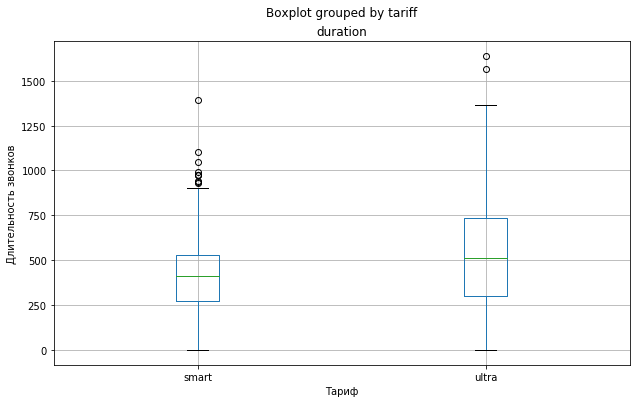

```python
revenue.boxplot(column='duration', by='tariff', figsize=(10, 6))
plt.ylabel('Длительность звонков')
plt.xlabel('Тариф')
```

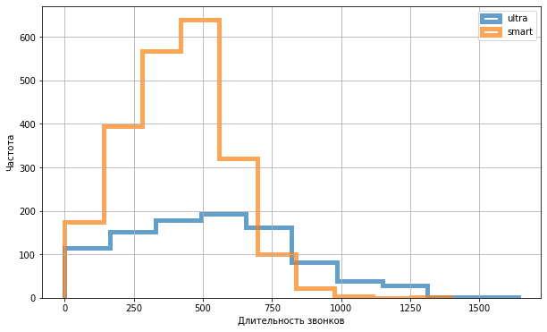

```python
ax = revenue.query('tariff == "ultra"')[['duration']].plot(kind='hist', histtype='step', linewidth=5, alpha=0.7)
(revenue.query('tariff == "smart"')[['duration']]
 .plot(kind='hist', histtype='step', linewidth=5, alpha=0.7, figsize=(10, 6), ax=ax, grid=True))
plt.legend(['ultra','smart'])
plt.ylabel('Частота')
plt.xlabel('Длительность звонков')
```

Пользователям тарифа smart требуется на 100 минут меньше разговора в месяц, чем пользователям тарифа ultra:  
медиана тарифа smart - 412 минут, медиана тарифа ultra - 514 минут.  
50% респондентов тарифа smart тратят на разговоры в месяц от 276 до 532 минут, это на 200 минут меньше, чем 50% респондентов тарифа ultra: от 301 до 736 минут.  
Нормальное распределение длительности разговоров за месяц пользователей разных тарифов уже разнится на 500 минут:  
у тарифа smart оно от 0 до 875 минут, у тарифа ultra - от 0 до 1375 минут.  
На графиках видно, что большинство клиентов тарифа smart не разговаривают более 530 минут в месяц. Тогда как длительность разговоров клиентов тарифа ultra распределена более равномерно и на более широком диапазоне почти до 1000 минут.

**Сравним распределение количества сообщений за месяц пользователей тарифов ultra и smart**

```
(-10, 200)
```

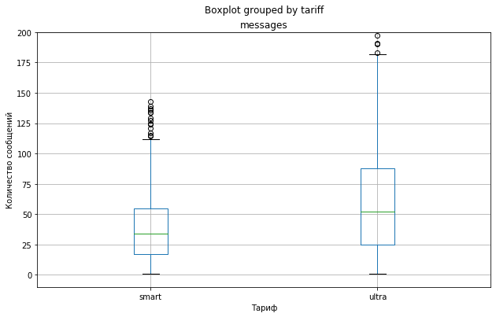

```python
revenue.boxplot(column='messages', by='tariff', figsize=(10, 6))
plt.ylabel('Количество сообщений')
plt.xlabel('Тариф')
plt.ylim(-10, 200)
```

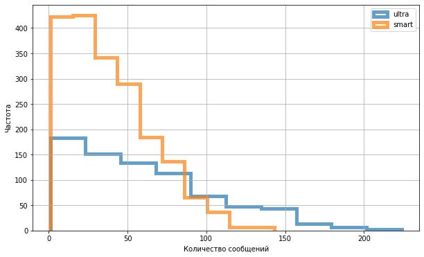

```python
ax = revenue.query('tariff == "ultra"')[['messages']].plot(kind='hist', histtype='step', linewidth=5, alpha=0.7)
(revenue.query('tariff == "smart"')[['messages']]
 .plot(kind='hist', histtype='step', linewidth=5, alpha=0.7, figsize=(10, 6), ax=ax, grid=True))
plt.legend(['ultra','smart'])
plt.ylabel('Частота')
plt.xlabel('Количество сообщений')
```

Пользователи тарифа smart отправляют на 35% меньше сообщений в месяц, чем пользователи тарифа ultra: медиана тарифа smart - 34 сообщения, медиана тарифа ultra - 52 сообщения.  
Половина респондентов тарифа smart отправляют за месяц от 17 до 55 сообщений, это на 37.5% меньше, чем половина респондентов тарифа ultra: от 25 до 88 сообщений.  
Нормальное распределение количества сообщений за месяц пользователей разных тарифов уже разнится на 40%: у тарифа smart оно от 0 до 112 сообщений, у тарифа ultra - от 0 до 185 сообщений.  
На графиках видно, что клиенты тарифа smart в основном ограничиваются 60 сообщениями в месяц. Распределение количества отправляемых в месяц сообщений клиентами тарифа ultra гораздо равномернее и шире, до 160 сообщений.

**Сравним распределение использованного за месяц интернет-трафика пользователями тарифов ultra и smart**

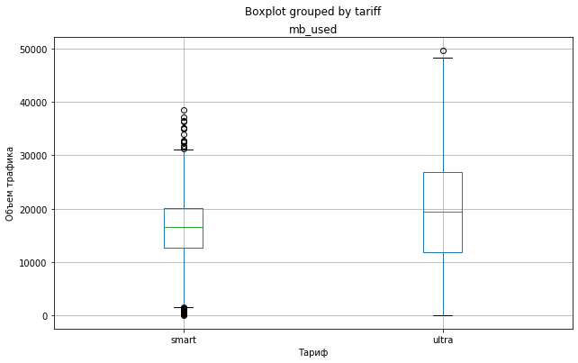

```python
revenue.boxplot(column='mb_used', by='tariff', figsize=(10, 6))
plt.ylabel('Объем трафика')
plt.xlabel('Тариф')
```

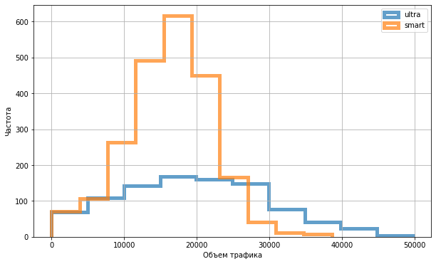

```python
ax = revenue.query('tariff == "ultra"')[['mb_used']].plot(kind='hist', histtype='step', linewidth=5, alpha=0.7)
(revenue.query('tariff == "smart"')[['mb_used']]
 .plot(kind='hist', histtype='step', linewidth=5, alpha=0.7, figsize=(10, 6), ax=ax, grid=True))
plt.legend(['ultra','smart'])
plt.ylabel('Частота')
plt.xlabel('Объем трафика')
```

Пользователям тарифа smart в месяц требуется на 3 гигабайта меньше интернет-трафика, чем пользователям тарифа ultra: медиана тарифа smart - 16514 мб (16 гб), медиана тарифа ultra - 19429 мб (19 гб). 50% респондентов тарифа smart используют в месяц от 12660 до 20057 мб (12.4 - 19.6 гб), а 50% респондентов тарифа ultra используют в месяц от 11875 до 26865 мб (11.6 - 26.2 гб). Нормальное распределение использованного интернет-трафика за месяц пользователей разных тарифов тоже разнится: у тарифа smart оно от 2000 до 31000 мб (2 - 30.3 гб), у тарифа ultra - от 0 до 48000 мб (47 гб).  
На графиках хорошо видно, что распределение потребляемого в месяц интернет-трафика клиентами тарифа smart довольно узкое и ограничено объемом 26800 мб (26 гб). Тогда как распределение потребляемого в месяц интернет-трафика клиентами тарифа ultra более равномерно распределено и значительно шире: до 40000 мб (39 гб).

### 4. Проверим гипотезы

#### Проверим гипотезу, что средняя выручка пользователей тарифов "Ультра" и "Смарт" различается

```python
revenue.groupby('tariff')['revenue'].describe()
```

| tariff | count | mean | std | min | 25% | 50% | 75% | max |
| --- | --- | --- | --- | --- | --- | --- | --- | --- |
| smart | 2223.0 | 1216.183527 | 778.279358 | 550.0 | 550.0 | 942.0 | 1634.89 | 6612.68 |
| ultra | 951.0 | 2060.952681 | 358.308962 | 1950.0 | 1950.0 | 1950.0 | 1950.00 | 4738.00 |

Исходя из показателей медианы, среднего и стандартного отклонения выручки пользователей тарифов ultra и smart можно предположить, что средняя выручка первых 2060 руб. сильно отличается от средней выручки вторых 1216 руб. Проверим это методами статистического анализа

Чтобы проверить гипотезу о равенстве средней выручки двух генеральных совокупностей - пользователей тарифа "Ультра" и тарифа "Смарт", применим метод **scipy.stats.ttest_ind()**. Данный метод применяется к двум независимым совокупностям, а пользователи тарифов "Ультра" и "Смарт" составляют независимые совокупности, так как это разные люди, поведение которых не зависит друг от друга.

Сформулируем нулевую гипотезу: Средняя выручка пользователей тарифа "Ультра" равна средней выручке пользователей тарифа "Смарт".  
Тогда альтернативная гипотеза будет звучать так: Средняя выручка пользователей тарифов "Ультра" и "Смарт" различается.

Зададим критический уровень статистической значимости alpha равным 5% и проверим нулевую гипотезу

```python
alpha = .05
results = st.ttest_ind(revenue.query('tariff == "ultra"')['revenue'], revenue.query('tariff == "smart"')['revenue'])
print('p-значение:', results.pvalue)

if results.pvalue < alpha:
    print('Отвергаем нулевую гипотезу')
else:
    print('Не получилось отвергнуть нулевую гипотезу')
```

```
p-значение: 1.7260911345849985e-195
Отвергаем нулевую гипотезу
```

Как видно, р-значение значительно меньше 5%, оно стремится к нулю.  
Поэтому мы отвергаем выдвинутую нами нулевую гипотезу о равенстве средней выручки пользователей тарифов "Ультра" и "Смарт".  
Значит, мы не отвергаем альтернативную гипотезу: *Средняя выручка пользователей тарифов "Ультра" и "Смарт" различается.*

#### Проверим гипотезу, что средняя выручка пользователей из Москвы отличается от выручки пользователей из других регионов

```python
revenue.query('city == "Москва"')['revenue'].describe()
```

```
count     610.000000
mean     1495.013098
std       738.591998
min       550.000000
25%       713.872500
50%      1650.620000
75%      1950.000000
max      5091.550000
Name: revenue, dtype: float64
```

```python
revenue.query('city != "Москва"')['revenue'].describe()
```

```
count    2564.000000
mean     1463.176283
std       792.689107
min       550.000000
25%       666.500000
50%      1471.965000
75%      1950.000000
max      6612.680000
Name: revenue, dtype: float64
```

Исходя из показателей медианы, среднего и стандартного отклонения выручки пользователей из Москвы и других регионов можно предположить, что средняя выручка москвичей 1495 руб. почти не отличается от средней выручки не москвичей 1463 руб. Проверим это методами статистического анализа

Чтобы проверить гипотезу о равенстве средней выручки двух генеральных совокупностей - пользователей из Москвы и пользователей из других регионов, также применим метод **scipy.stats.ttest_ind()**, который применяется к двум независимым совокупностям. Ведь жители Москвы и других регионов - это разные люди, значит они составляют две независимые совокупности.

Сформулируем нулевую гипотезу: Средняя выручка пользователей из Москвы равна средней выручке пользователей из других регионов.  
Тогда альтернативная гипотеза будет звучать так: Средняя выручка пользователей из Москвы отличается от выручки пользователей из других регионов.

Зададим критический уровень статистической значимости alpha равным 5% и проверим нулевую гипотезу

```python
alpha = .05
results = st.ttest_ind(revenue.query('city == "Москва"')['revenue'], revenue.query('city != "Москва"')['revenue'])
print('p-значение:', results.pvalue)

if results.pvalue < alpha:
    print('Отвергаем нулевую гипотезу')
else:
    print('Не получилось отвергнуть нулевую гипотезу')
```

```
p-значение: 0.3665653499723861
Не получилось отвергнуть нулевую гипотезу
```

Как видно, р-значение более 36% и значительно превышает уровень статистической значимости.  
Значит, мы не отвергаем нулевую гипотезу о том, что *Cредняя выручка пользователей из Москвы равна средней выручке пользователей из других регионов.*  
Поэтому мы отвергаем альтернативную гипотезу: Средняя выручка пользователей из Москвы отличается от выручки пользователей из других регионов.

### 5. Вывод

Перед нами стояла цель - из двух тарифов "Ультра" и "Смарт" федерального оператора сотовой связи - телеком компании «Мегалайн» определить, какой из них является перспективным для развития телеком компанией в дальнейшем.  
В нашем распоряжении были данные 500 пользователей «Мегалайна»: кто они, откуда, каким тарифом пользуются, сколько звонков и сообщений каждый отправил за 2018 год.

Для проведения анализа поведения клиентов и принятия решения, какой тариф лучше, была проведена предобработка данных:

Столбцы с датами в таблицах calls, internet, messages и users приведены к требуемому типу datetime.  
Столбец churn_date таблицы users был удален, так как количество информации в столбце составляло всего 7.6%, и сама информация о расторжении клиентами договоров не влияла на анализ действующих тарифов оператора связи.  
Столбец duration таблицы calls и столбец mb_used таблицы internet содержали 20% и 13% соответственно нулевых данных. Так как объем нулевых данных достаточно большой, а нулевые звонки и интернет-трафик, по-видимому, тарифицируются оператором как факт пользования респондентом услугой связи, было решено заменить нули на единицы.

**Для каждого пользователя было посчитано:**

- количество сделанных звонков и израсходованных минут разговора по месяцам
- количество отправленных сообщений по месяцам
- объем израсходованного интернет-трафика по месяцам
- помесячная выручка.

**Был проведен сравнительный анализ основных метрик тарифов "Ультра" и "Смарт":**

- длительность разговоров пользователей в месяц
- количество отправленных пользователями сообщений в месяц
- объем использованного интернет-трафика пользователями в месяц.

**Ряды пользователей тарифа "Ультра" более неоднородны: в них есть и те, кто очень много разговаривает и те, кто отправляет очень много сообщений. Значит, у этой группы есть потенциал роста в части доходности для оператора связи "Мегалайн".**

Для проведения сравнительного анализа основной метрики - средней выручки тарифов "Ультра" и "Смарт", были сформулированы и проанализированы две гипотезы:

1. Средняя выручка пользователей тарифов "Ультра" и "Смарт" различается
2. Средняя выручка пользователей из Москвы отличается от выручки пользователей из других регионов

В результате проведенного статистического анализа мы выяснили, что:

**1. Средняя выручка пользователей тарифов "Ультра" и "Смарт" различается. Причем средняя выручка тарифа "Ультра" составляет 170% от средней выручки тарифа "Смарт".**

**2. Cредняя выручка пользователей из Москвы не отличается от средней выручки пользователей из других регионов. Показатели почти равны: 1495 руб. и 1463 руб. соответственно.**

Таким образом мы установили, что наиболее перспективным тарифом в плане роста доходности для оператора сотовой связи "Мегалайн" является тариф "Ультра". Причем развивать его следует не только в Москве, а на всей территории Российской Федерации.